# Momentary HF Radio Propagation Disruption GRB 221009A Detected by the Weak Signal Reporting Network

W. Kyle Hamilton

21 November 2022

# Introduction

On October 9th, 2022 multiple sources reported the detection of GRB 221009A including satellite Dichiara et al. (2022) Frederiks et al. (2022) and ground based observers Guha & Nicholson (2022). Among these reports included observations of sudden ionospheric disturbances in the hours after the detection of GRB 221009A Hayes & Gallagher (2022). These disturbances were caused by the high energy rays emitted from GRB 221009A which in turn had an ionizing effect on ionosphere which resulted in the disruption of HF radio transmissions. Documenting this effect on radio propagation we utilize the Weak Signal Reporting Network (WSPR) which is a global collection of Amateur Radio stations which collect and transmit two minute digital beacon signals on the HF Amateur Radio frequency bands. Data coming from WSPR has been used to previously study the ionosphere. Frissell et al. (2019) Frissell et al. (2022)

# Setup Workspace

```r
# Load packages
library(readr)
library(ggplot2)
library(dplyr)
library(tidyr)
library(lubridate)
library(DT)

# Colorblind colors
# Steenwyk & Rokas (2021). https://doi.org/10.1128/MRA.00871-21
vibrant_seven <- c("#0077BB", "#EE7733", "#33BBEE", "#CC3311", "#009988", "#EE3377", "#BBBBBB")
bright_seven <- c("#4477AA", "#228833", "#AA3377", "#BBBBBB", "#66CCEE", "#CCBB44", "#EE6677")

# World map data from tidyverse
world <- map_data("world")
```

# WSPR Data

## Load WPSR Data

```r
WSPRLive20221009 <- read_delim(
  "WSPRLive20221009.tsv",
  delim = "\t",
  escape_double = FALSE,
  col_types = cols(
    time = col_datetime(format = "%Y-%m-%d %H:%M:%S"),
    band = col_factor(
      levels = c(
        "-1",
        "0",
        "1",
        "3",
        "5",
        "7",
        "10",
        "14",
        "18",
        "21",
        "24",
        "28",
        "50",
        "70",
        "144",
        "432",
        "1296"
      )
    )
  ),
  trim_ws = TRUE
)
```

## Filter WSPR Data

```r
# Add the number of occurrences in n based on band and time reported
WSPRLive20221009 <- WSPRLive20221009 %>%
  group_by(band, time) %>%
  add_count() %>%
  ungroup()

# Remove reception reports recorded at odd numbered intervals
WSPRLive20221009 <- WSPRLive20221009 %>%
  filter(n > 13)

# Keep just the total number of observations for each band and time
WSPR_Extract <- WSPRLive20221009 %>%
  distinct(band, time, n)

# Narrow the time frame down so it's easier to work with
WSPR_Extract_TimeLimit <- WSPRLive20221009 %>%
  distinct(band, time, n) %>%
  filter(time > ymd_hms("2022-10-09 12:50:00")) %>%
  filter(time < ymd_hms("2022-10-09 15:50:00"))

# Keep only bands that have enough observations
WSPR_Extract_TimeLimit_LessBands <- WSPR_Extract_TimeLimit %>%
  filter(band == 3 | band == 7 | band == 10 | band == 14 | band == 18 | band == 21 | band == 28)
```

# Reception Reports

## Graphs

### Count of Reception Reports

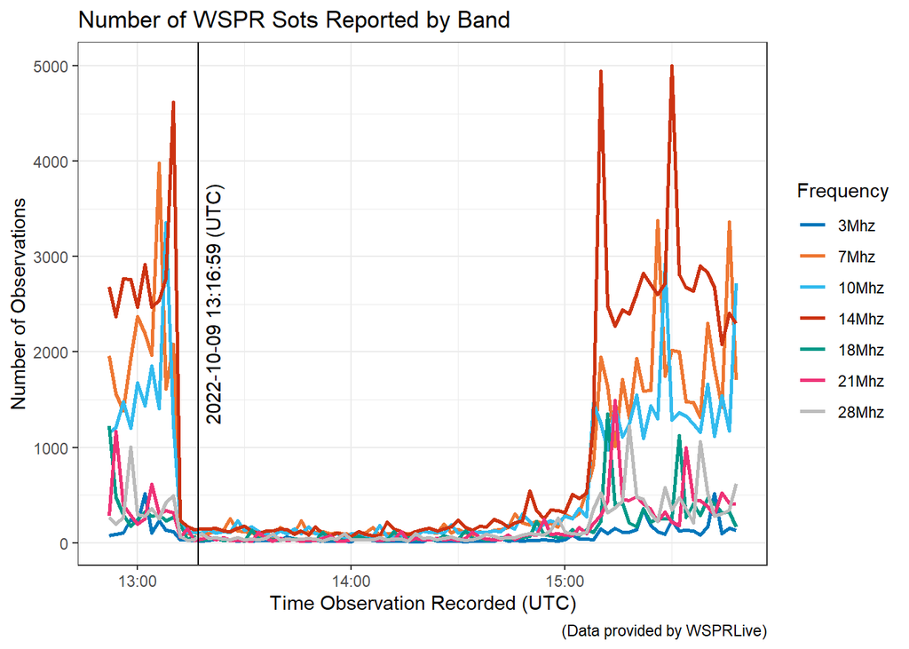

```r
WSPR_Extract_TimeLimit_LessBands %>%
  ggplot(aes(time, n, group = band, col = band)) +
  geom_line(linewidth = 1) +
  scale_colour_manual(
    values = vibrant_seven,
    name = "Frequency",
    breaks = c("3", "7", "10", "14", "18", "21", "28"),
    labels = c("3Mhz", "7Mhz", "10Mhz", "14Mhz", "18Mhz", "21Mhz", "28Mhz")
  ) +
  geom_vline(xintercept = ymd_hms("2022-10-09 13:16:59"),
             linewidth = 0.5) +
  annotate("text",
           x = ymd_hms("2022-10-09 13:16:59"),
           y = 2500,
           angle = 90,
           label = "\n2022-10-09 13:16:59 (UTC)") +
  ggtitle("Number of WSPR Sots Reported by Band") +
  xlab("Time Observation Recorded (UTC)") +
  ylab("Number of Observations") +
  labs(caption = "(Data provided by WSPRLive)") +
  theme_bw()
```

Graph of log transformed reception reports based on time and band. Black line is for when the GRB occurred in Gotz et al 2022 https://gcn.gsfc.nasa.gov/other/221009A.gcn3

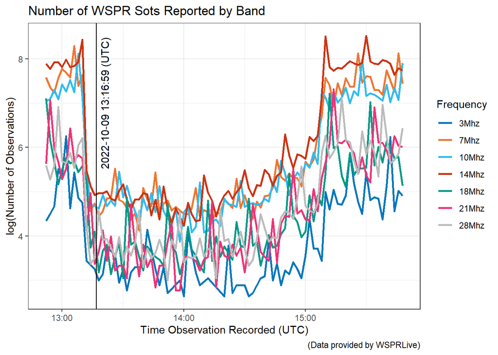

```r
# Graph of log transformed reception reports based on time and band
# Black line is for when the GRB occurred in Gotz et al 2022
# https://gcn.gsfc.nasa.gov/other/221009A.gcn3
WSPR_Extract_TimeLimit_LessBands %>%
  ggplot(aes(time, log(n), group = band, col = band)) +
  geom_line(linewidth = 1) +
  scale_colour_manual(
    values = vibrant_seven,
    name = "Frequency",
    breaks = c("3", "7", "10", "14", "18", "21", "28"),
    labels = c("3Mhz", "7Mhz", "10Mhz", "14Mhz", "18Mhz", "21Mhz", "28Mhz")
  ) +
  geom_vline(xintercept = ymd_hms("2022-10-09 13:16:59"),
             linewidth = 0.5) +
  annotate("text",
           x = ymd_hms("2022-10-09 13:16:59"),
           y = 7,
           angle = 90,
           label = "\n2022-10-09 13:16:59 (UTC)") +
  ggtitle("Number of WSPR Sots Reported by Band") +
  xlab("Time Observation Recorded (UTC)") +
  ylab("log(Number of Observations)") +
  labs(caption = "(Data provided by WSPRLive)") +
  theme_bw()
```

### Summary Data

```r
summaryData <- WSPRLive20221009 %>%
  group_by(band, time) %>%
  summarise(
    minDistance = min(distance),
    maxDistance = max(distance),
    medianDistance = median(distance),
    meanDistance = mean(distance),
    sdDistance = sd(distance),
    minPower = min(power),
    maxPower = max(power),
    medianPower = median(power),
    meanPower = mean(power),
    sdPower = sd(power),
    minSNR = min(snr),
    maxSNR = max(snr),
    medianSNR = median(snr),
    meanSNR = mean(snr),
    sdSNR = sd(snr),
    n = n()
  ) %>%
  ungroup()
# summaryData <- summaryData %>%
#   filter(time > ymd_hms("2022-10-09 12:50:00")) %>%
#   filter(time < ymd_hms("2022-10-09 15:50:00"))

summaryData3 <- summaryData %>%
  filter(band == 3)

summaryData7 <- summaryData %>%
  filter(band == 7)

summaryData10 <- summaryData %>%
  filter(band == 10)

summaryData14 <- summaryData %>%
  filter(band == 14)

summaryData18 <- summaryData %>%
  filter(band == 18)

summaryData21 <- summaryData %>%
  filter(band == 21)

summaryData28 <- summaryData %>%
  filter(band == 28)

summaryDataGroup <- summaryData %>%
  filter(band == 3 | band == 7 | band == 10 | band == 14)
```

### Graphs of Maximum SNR

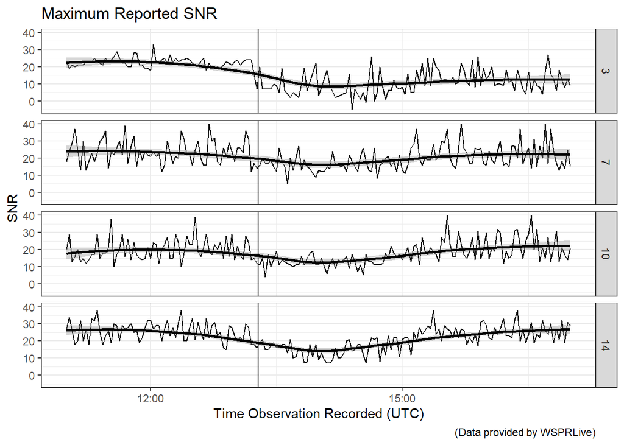

```r
ggplot(summaryDataGroup, aes(time, maxSNR)) +
  geom_line() +
  geom_smooth(method = "loess", color = "black") +
    scale_colour_manual(
    values = vibrant_seven,
    name = "Frequency",
    breaks = "3",
    labels = "3Mhz") +
  geom_vline(xintercept = ymd_hms("2022-10-09 13:16:59"),
             linewidth = 0.5)+
  ggtitle("Maximum Reported SNR") +
  xlab("Time Observation Recorded (UTC)") +
  ylab("SNR") +
  labs(caption = "(Data provided by WSPRLive)") +
  facet_grid(rows = vars(band)) +
  theme_bw()
```

#### 80 Meters (3Mhz)

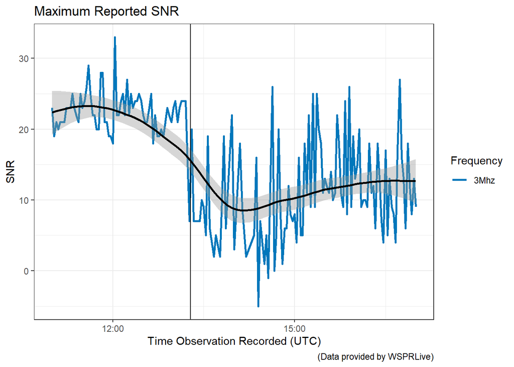

```r
ggplot(summaryData3, aes(time, maxSNR, group = band, col = band)) +
  geom_line(linewidth = 1) +
  geom_smooth(method = "loess", color = "black") +
    scale_colour_manual(
    values = vibrant_seven,
    name = "Frequency",
    breaks = "3",
    labels = "3Mhz") +
  geom_vline(xintercept = ymd_hms("2022-10-09 13:16:59"),
             linewidth = 0.5)+
  ggtitle("Maximum Reported SNR") +
  xlab("Time Observation Recorded (UTC)") +
  ylab("SNR") +
  labs(caption = "(Data provided by WSPRLive)") +
  theme_bw()
```

#### 40 Meters (7Mhz)

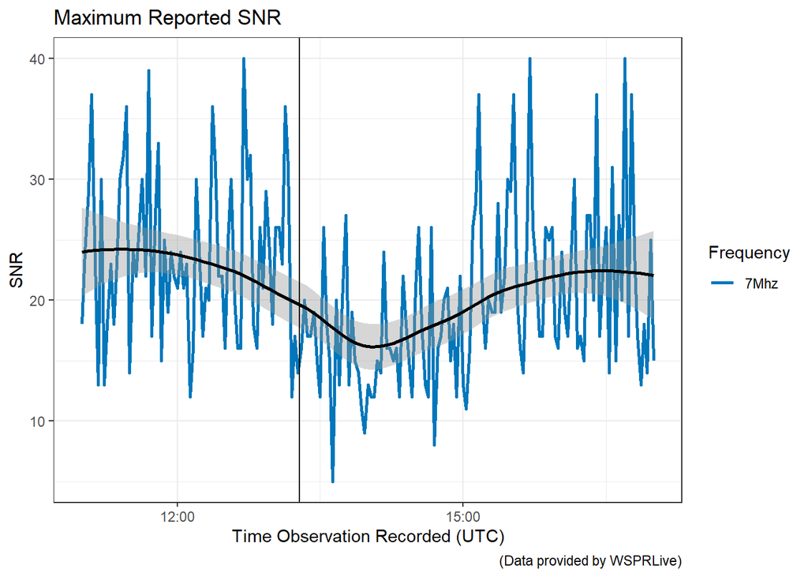

```r
ggplot(summaryData7, aes(time, maxSNR, group = band, col = band)) +
  geom_line(linewidth = 1) +
  geom_smooth(method = "loess", color = "black") +
    scale_colour_manual(
    values = vibrant_seven,
    name = "Frequency",
    breaks = "7",
    labels = "7Mhz") +
  geom_vline(xintercept = ymd_hms("2022-10-09 13:16:59"),
             linewidth = 0.5)+
  ggtitle("Maximum Reported SNR") +
  xlab("Time Observation Recorded (UTC)") +
  ylab("SNR") +
  labs(caption = "(Data provided by WSPRLive)") +
  theme_bw()
```

#### 20 Meters (14Mhz)

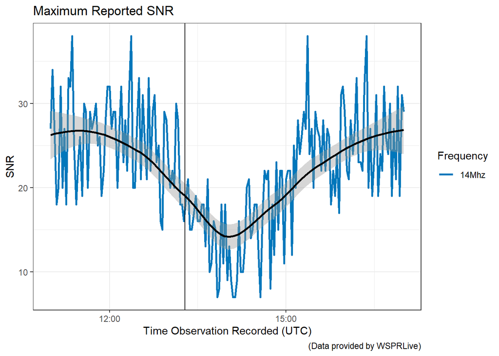

```r
ggplot(summaryData14, aes(time, maxSNR, group = band, col = band)) +
  geom_line(linewidth = 1) +
  geom_smooth(method = "loess", color = "black") +
    scale_colour_manual(
    values = vibrant_seven,
    name = "Frequency",
    breaks = "14",
    labels = "14Mhz") +
  geom_vline(xintercept = ymd_hms("2022-10-09 13:16:59"),
             linewidth = 0.5)+
  ggtitle("Maximum Reported SNR") +
  xlab("Time Observation Recorded (UTC)") +
  ylab("SNR") +
  labs(caption = "(Data provided by WSPRLive)") +
  theme_bw()
```

#### 15 Meters (21Mhz)

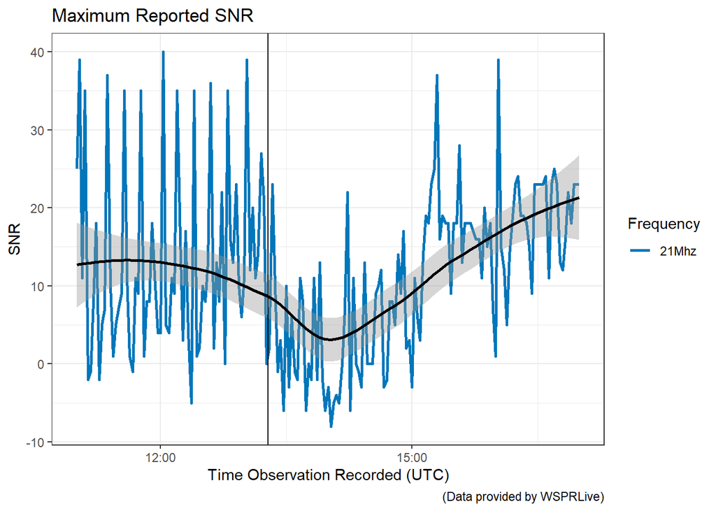

```r
ggplot(summaryData21, aes(time, maxSNR, group = band, col = band)) +
  geom_line(linewidth = 1) +
  geom_smooth(method = "loess", color = "black") +
    scale_colour_manual(
    values = vibrant_seven,
    name = "Frequency",
    breaks = "21",
    labels = "21Mhz") +
  geom_vline(xintercept = ymd_hms("2022-10-09 13:16:59"),
             linewidth = 0.5)+
  ggtitle("Maximum Reported SNR") +
  xlab("Time Observation Recorded (UTC)") +
  ylab("SNR") +
  labs(caption = "(Data provided by WSPRLive)") +
  theme_bw()
```

#### 10 Meters (28Mhz)

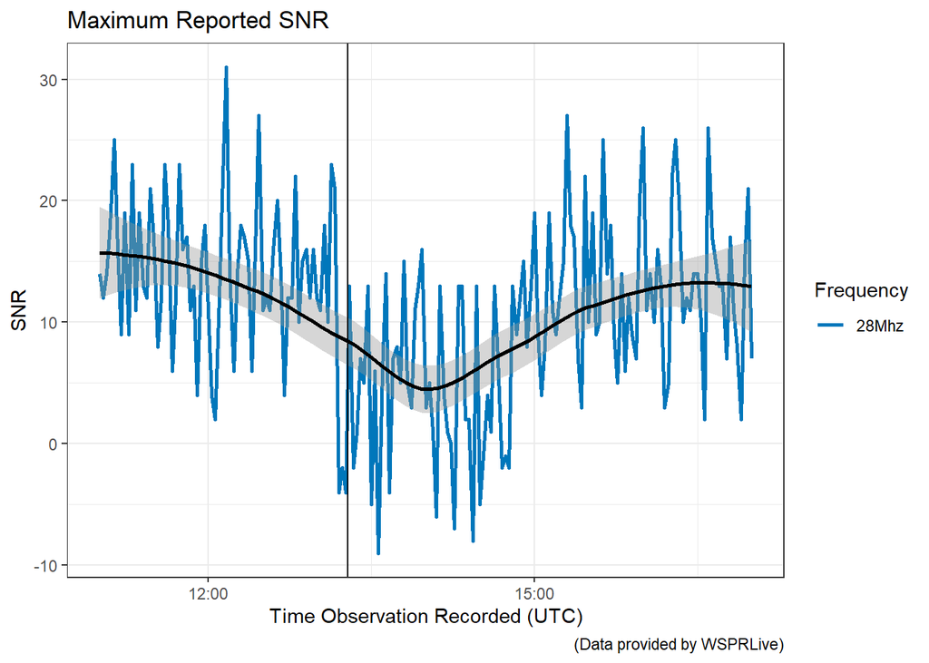

```r
ggplot(summaryData28, aes(time, maxSNR, group = band, col = band)) +
  geom_line(linewidth = 1) +
  geom_smooth(method = "loess", color = "black") +
    scale_colour_manual(
    values = vibrant_seven,
    name = "Frequency",
    breaks = "28",
    labels = "28Mhz") +
  geom_vline(xintercept = ymd_hms("2022-10-09 13:16:59"),
             linewidth = 0.5)+
  ggtitle("Maximum Reported SNR") +
  xlab("Time Observation Recorded (UTC)") +
  ylab("SNR") +
  labs(caption = "(Data provided by WSPRLive)") +
  theme_bw()
```

## Table

```r
datatable(WSPR_Extract_TimeLimit_LessBands, filter = 'top', colnames = c('Time', 'Band', 'Number of Observations'), rownames = FALSE)
```

| Time | Band | Number of Observations |
| --- | --- | --- |
| 2022-10-09T12:52:00Z | 3 | 77 |
| 2022-10-09T12:52:00Z | 7 | 1964 |
| 2022-10-09T12:52:00Z | 10 | 1153 |
| 2022-10-09T12:52:00Z | 14 | 2682 |
| 2022-10-09T12:52:00Z | 18 | 1222 |
| 2022-10-09T12:52:00Z | 28 | 268 |
| 2022-10-09T12:52:00Z | 21 | 278 |
| 2022-10-09T12:54:00Z | 3 | 90 |
| 2022-10-09T12:54:00Z | 7 | 1561 |
| 2022-10-09T12:54:00Z | 10 | 1212 |

[output cut: 600 more lines]

# Reception Maps

## 20 meters at 12:32 UTC

[figure not shown]

```r
# Reception Maps for 20 meters at 12:32 UTC
MapData_20Meter_1232 <- WSPRLive20221009 %>%
  filter(band == 14) %>%
  filter(time > ymd_hms("2022-10-09 12:30:00")) %>%
  filter(time < ymd_hms("2022-10-09 12:34:00")) %>%
  select(rx_sign,rx_lat,rx_lon,tx_sign,tx_lat,tx_lon) %>%
  mutate(link = row_number()) %>%
  pivot_longer(
    !link,
    names_to = c("txrx", ".value"),
    names_sep = "_"
  )
ggplot(MapData_20Meter_1232) +
  geom_polygon(data=world, aes(x=long, y=lat, group=group)) +
  geom_line(aes(x=lon, y=lat, group = link), color="#CC3311", linewidth=0.5) +
  geom_point(data=MapData_20Meter_1232, aes(x=lon, y=lat, colour = txrx), alpha=0.7) +
  scale_colour_manual(
    values = vibrant_seven,
    name = "Site Type",
    breaks = c("rx", "tx"),
    labels = c("Reception", "Transmission")
  ) +
  ggtitle("Tranmission and Reception Locations",
          subtitle = "20 Meter Band at 13:32:00 UTC") +
  xlab("Longitude") +
  ylab("Latitude") +
  labs(caption = "(Data provided by WSPRLive)") +
  theme_bw() +
  coord_quickmap()
```

## 40 meters at 12:32 UTC

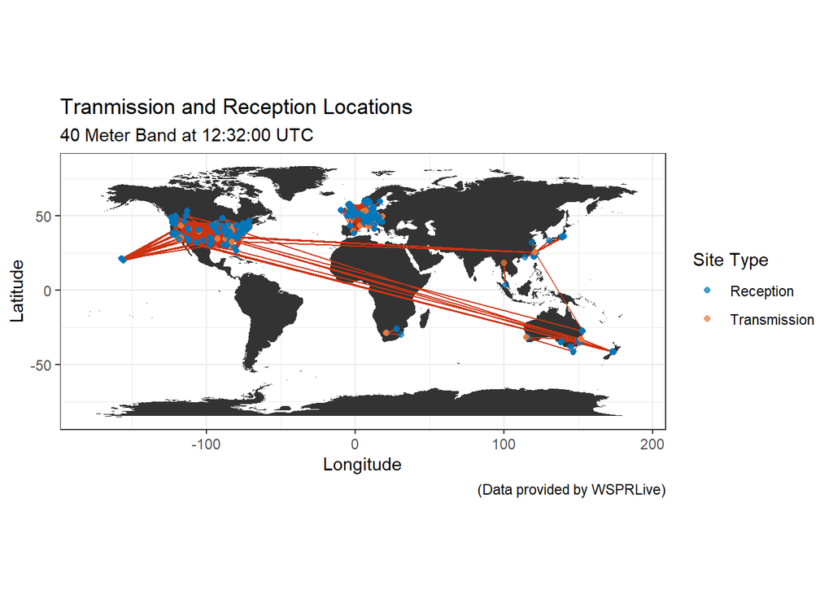

```r
# Reception Maps for 40 meters at 12:32 UTC
MapData_40Meter_1232 <- WSPRLive20221009 %>%
  filter(band == 7) %>%
  filter(time > ymd_hms("2022-10-09 12:30:00")) %>%
  filter(time < ymd_hms("2022-10-09 12:34:00")) %>%
  select(rx_sign,rx_lat,rx_lon,tx_sign,tx_lat,tx_lon) %>%
  mutate(link = row_number()) %>%
  pivot_longer(
    !link,
    names_to = c("txrx", ".value"),
    names_sep = "_"
  )

ggplot(MapData_40Meter_1232) +
  geom_polygon(data=world, aes(x=long, y=lat, group=group)) +
  geom_line(aes(x=lon, y=lat, group = link), color="#CC3311", linewidth=0.5) +
  geom_point(data=MapData_40Meter_1232, aes(x=lon, y=lat, colour = txrx), alpha=0.7) +
  scale_colour_manual(
    values = vibrant_seven,
    name = "Site Type",
    breaks = c("rx", "tx"),
    labels = c("Reception", "Transmission")
  ) +
  ggtitle("Tranmission and Reception Locations",
          subtitle = "40 Meter Band at 12:32:00 UTC") +
  xlab("Longitude") +
  ylab("Latitude") +
  labs(caption = "(Data provided by WSPRLive)") +
  theme_bw() +
  coord_quickmap()
```

## 20 meters at 13:32 UTC

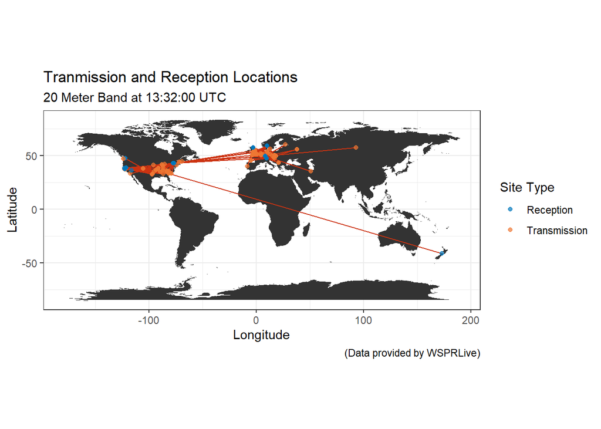

```r
# Reception Maps for 20 meters at 13:32 UTC
MapData_20Meter_1332 <- WSPRLive20221009 %>%
  filter(band == 14) %>%
  filter(time > ymd_hms("2022-10-09 13:30:00")) %>%
  filter(time < ymd_hms("2022-10-09 13:34:00")) %>%
  select(rx_sign,rx_lat,rx_lon,tx_sign,tx_lat,tx_lon) %>%
  mutate(link = row_number()) %>%
  pivot_longer(
    !link,
    names_to = c("txrx", ".value"),
    names_sep = "_"
  )
ggplot(MapData_20Meter_1332) +
  geom_polygon(data=world, aes(x=long, y=lat, group=group)) +
  geom_line(aes(x=lon, y=lat, group = link), color="#CC3311", linewidth=0.5) +
  geom_point(data=MapData_20Meter_1332, aes(x=lon, y=lat, colour = txrx), alpha=0.7) +
  scale_colour_manual(
    values = vibrant_seven,
    name = "Site Type",
    breaks = c("rx", "tx"),
    labels = c("Reception", "Transmission")
  ) +
  ggtitle("Tranmission and Reception Locations",
          subtitle = "20 Meter Band at 13:32:00 UTC") +
  xlab("Longitude") +
  ylab("Latitude") +
  labs(caption = "(Data provided by WSPRLive)") +
  theme_bw() +
  coord_quickmap()
```

## 40 meters at 13:32 UTC

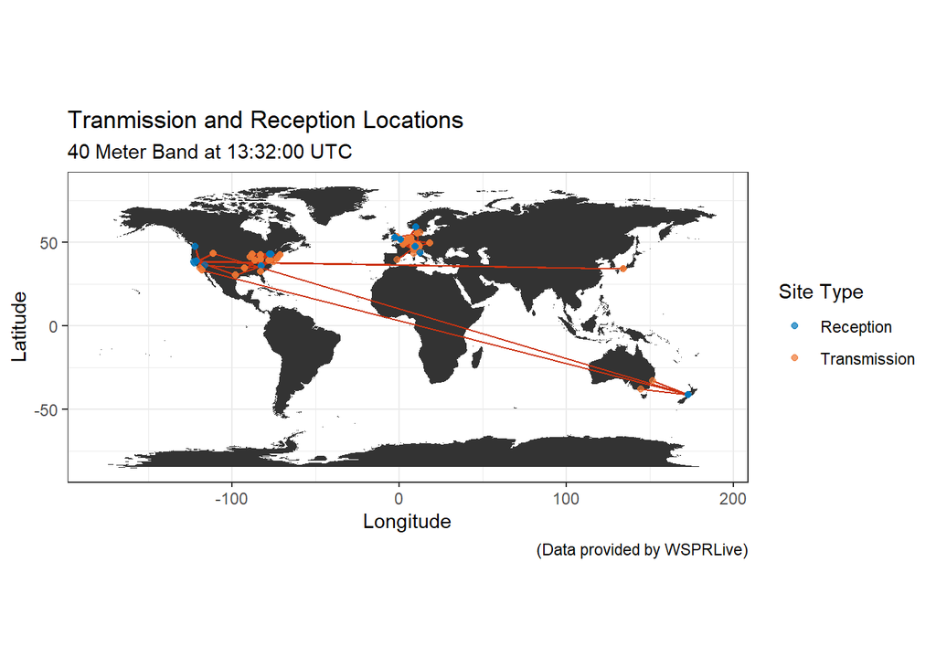

```r
# Reception Maps for 40 meters at 13:32 UTC
MapData_40Meter_1332 <- WSPRLive20221009 %>%
  filter(band == 7) %>%
  filter(time > ymd_hms("2022-10-09 13:30:00")) %>%
  filter(time < ymd_hms("2022-10-09 13:34:00")) %>%
  select(rx_sign,rx_lat,rx_lon,tx_sign,tx_lat,tx_lon) %>%
  mutate(link = row_number()) %>%
  pivot_longer(
    !link,
    names_to = c("txrx", ".value"),
    names_sep = "_"
  )

ggplot(MapData_40Meter_1332) +
  geom_polygon(data=world, aes(x=long, y=lat, group=group)) +
  geom_line(aes(x=lon, y=lat, group = link), color="#CC3311", linewidth=0.5) +
  geom_point(data=MapData_40Meter_1332, aes(x=lon, y=lat, colour = txrx), alpha=0.7) +
  scale_colour_manual(
    values = vibrant_seven,
    name = "Site Type",
    breaks = c("rx", "tx"),
    labels = c("Reception", "Transmission")
  ) +
  ggtitle("Tranmission and Reception Locations",
          subtitle = "40 Meter Band at 13:32:00 UTC") +
  xlab("Longitude") +
  ylab("Latitude") +
  labs(caption = "(Data provided by WSPRLive)") +
  theme_bw() +
  coord_quickmap()
```

# References

Dichiara, S., Gropp, J. D., Kennea, J. A., Kuin, N. P. M., Lien, A. Y., Marshall, F. E., Tohuvavohu, A., Williams, M. A., & Neil Gehrels Swift Observatory Team. (2022). Swift J1913.1+1946 a new bright hard X-ray and optical transient. *GRB Coordinates Network*, *32632*, 1.

Feroci, M., Costa, E., Soffitta, P., Del Monte, E., Di Persio, G., Donnarumma, I., Evangelista, Y., Frutti, M., Lapshov, I., Lazzarotto, F., Mastropietro, M., Morelli, E., Pacciani, L., Porrovecchio, G., Rapisarda, M., Rubini, A., Tavani, M., & Argan, A. (2007). SuperAGILE: The hard x-ray imager for the AGILE space mission. *Nuclear Instruments and Methods in Physics Research Section A: Accelerators, Spectrometers, Detectors and Associated Equipment*, *581*(3), 728–754. https://doi.org/10.1016/j.nima.2007.07.147

Frederiks, D., Lysenko, A., Ridnaia, A., Svinkin, D., Tsvetkova, A., Ulanov, M., Cline, T., & Konus-Wind Team. (2022). Konus-Wind detection of GRB 221009A. *GRB Coordinates Network*, *32668*, 1.

Frissell, N. A., Kaeppler, S. R., Sanchez, D. F., Perry, G. W., Engelke, W. D., Erickson, P. J., Coster, A. J., Ruohoniemi, J. M., Baker, J. B. H., & West, M. L. (2022). First observations of large scale traveling ionospheric disturbances using automated amateur radio receiving networks. *Geophysical Research Letters*, *49*(5), e2022GL097879. https://doi.org/https://doi.org/10.1029/2022GL097879

Frissell, N. A., Vega, J. S., Markowitz, E., Gerrard, A. J., Engelke, W. D., Erickson, P. J., Miller, E. S., Luetzelschwab, R. C., & Bortnik, J. (2019). High-frequency communications response to solar activity in september 2017 as observed by amateur radio networks. *Space Weather*, *17*(1), 118–132. https://doi.org/https://doi.org/10.1029/2018SW002008

Grolemund, G., & Wickham, H. (2011). Dates and times made easy with lubridate. *Journal of Statistical Software*, *40*(3), 1–25. https://www.jstatsoft.org/v40/i03/

Guha, A., & Nicholson, P. (2022). GRB221009A: Ionospheric disturbance observed in India. *GRB Coordinates Network*, *32745*, 1.

Hayes, L. A., & Gallagher, P. T. (2022). A significant sudden ionospheric disturbance associated with gamma-ray burst GRB 221009A. *Research Notes of the AAS*, *6*(10), 222. https://doi.org/10.3847/2515-5172/ac9d2f

Steenwyk, J. L., & Rokas, A. (2021). Ggpubfigs: Colorblind-friendly color palettes and ggplot2 graphic system extensions for publication-quality scientific figures. *Microbiology Resource Announcements*, *10*(44), e00871–21. https://doi.org/10.1128/MRA.00871-21

Wickham, H. (2016). *ggplot2: Elegant graphics for data analysis*. Springer-Verlag New York. https://ggplot2.tidyverse.org

Wickham, H., François, R., Henry, L., & Müller, K. (2022). *Dplyr: A grammar of data manipulation*. https://CRAN.R-project.org/package=dplyr

Wickham, H., & Girlich, M. (2022). *Tidyr: Tidy messy data*. https://CRAN.R-project.org/package=tidyr

Wickham, H., Hester, J., & Bryan, J. (2022). *Readr: Read rectangular text data*. https://CRAN.R-project.org/package=readr

Xie, Y., Cheng, J., & Tan, X. (2022). *DT: A wrapper of the JavaScript library ’DataTables’*. https://CRAN.R-project.org/package=DT